# Final Project: Is there a correlation between the popularity of manga and the ranking of their anime adaptations?

Sijie Wu

Aug 7, 2024

## Research Question and Dataset Introduction

The research question driving this analysis is: **“Is there a correlation between the popularity of manga and the ranking of their anime adaptations?”** To explore this, we utilized two comprehensive datasets sourced from Kaggle. The first dataset, Top Anime Ranked, is derived from MyAnimeList.net, a prominent platform for anime enthusiasts. This dataset encompasses a wide range of information, including unique identifiers (UID), titles, rankings, stream types, episodes, start and end dates, member counts, and user scores. It offers a detailed view of anime popularity, duration, and user ratings, making it a valuable resource for statistical analysis, machine learning applications, and trend exploration in anime viewership.

The second dataset, Best-Selling Manga, lists the most successful Japanese manga series based on the number of collected tankōbon volumes sold. This dataset includes manga series with at least 20 million copies in circulation, providing a reliable measure of their popularity. The data is organized by the highest circulation estimates recorded from credible sources, ensuring accurate representation of manga sales. By analyzing these datasets, we aim to uncover patterns and correlations between the success of manga and the performance of their corresponding anime adaptations, providing insights into the factors that contribute to the popularity of these media forms.

## Data Processing

#### Data Intake

```r
library(readr)

# Import the Top Anime Ranked dataset
Anime_rank <- read_csv("/Users/vivienwu/Downloads/Anime_rank.csv")
# Import the Best-Selling Manga dataset
best_selling_manga <- read_csv("/Users/vivienwu/Downloads/best-selling-manga.csv")
# Print the first few rows of each dataset to confirm successful import
head(Anime_rank)
```

| UID | Title | Rank | Stream type | Episodes | Start date | End date | Members | Score |
| --- | --- | --- | --- | --- | --- | --- | --- | --- |
| 1 | Sousou no Frieren | 1 | TV | 28 | Sep 2023 | Mar 2024 | 800615 | 9.35 |
| 2 | Fullmetal Alchemist: Brotherhood | 2 | TV | 64 | Apr 2009 | Jul 2010 | 3373923 | 9.09 |
| 3 | Steins;Gate | 3 | TV | 24 | Apr 2011 | Sep 2011 | 2584616 | 9.07 |
| 4 | Gintama° | 4 | TV | 51 | Apr 2015 | Mar 2016 | 636631 | 9.06 |
| 5 | Shingeki no Kyojin Season 3 Part 2 | 5 | TV | 10 | Apr 2019 | Jul 2019 | 2305044 | 9.05 |
| 6 | Gintama: The Final | 6 | Movie | 1 | Jan 2021 | Jan 2021 | 153317 | 9.04 |

```r
head(best_selling_manga)
```

| Manga series | Author(s) | Publisher | Demographic | No. of collected volumes | Serialized | Approximate sales in million(s) | Average sales per volume in million(s) |
| --- | --- | --- | --- | --- | --- | --- | --- |
| One Piece | Eiichiro Oda | Shueisha | Shōnen | 104 | 1997–present | 516.6 | 4.97 |
| Golgo 13 | Takao Saito, Saito Production | Shogakukan | Seinen | 207 | 1968–present | 300.0 | 1.45 |
| Case Closed / Detective Conan | Gosho Aoyama | Shogakukan | Shōnen | 102 | 1994–present | 270.0 | 2.65 |
| Dragon Ball | Akira Toriyama | Shueisha | Shōnen | 42 | 1984–1995 | 260.0 | 6.19 |
| Doraemon | Fujiko F. Fujio | Shogakukan | Children | 45 | 1969–1996 | 250.0 | 4.71 |
| Naruto | Masashi Kishimoto | Shueisha | Shōnen | 72 | 1999–2014 | 250.0 | 3.47 |

#### Data Wrangling

The data wrangling process involved several key steps to prepare the datasets for analysis and visualization.

```r
# Load packages
library(dplyr)
```

```r
library(tidyr)
library(readr)
library(stringr)
library(ggplot2)

# View the structure of the datasets
str(Anime_rank)
```

```
## spc_tbl_ [8,650 × 9] (S3: spec_tbl_df/tbl_df/tbl/data.frame)
##  $ UID        : num [1:8650] 1 2 3 4 5 6 7 8 9 10 ...
##  $ Title      : chr [1:8650] "Sousou no Frieren" "Fullmetal Alchemist: Brotherhood" "Steins;Gate" "Gintama°" ...
##  $ Rank       : num [1:8650] 1 2 3 4 5 6 7 8 9 10 ...
##  $ Stream type: chr [1:8650] "TV" "TV" "TV" "TV" ...
##  $ Episodes   : num [1:8650] 28 64 24 51 10 1 51 148 110 13 ...
##  $ Start date : chr [1:8650] "Sep 2023" "Apr 2009" "Apr 2011" "Apr 2015" ...
##  $ End date   : chr [1:8650] "Mar 2024" "Jul 2010" "Sep 2011" "Mar 2016" ...
##  $ Members    : num [1:8650] 800615 3373923 2584616 636631 2305044 ...
##  $ Score      : num [1:8650] 9.35 9.09 9.07 9.06 9.05 9.04 9.03 9.03 9.02 9.02 ...
##  - attr(*, "spec")=
##   .. cols(
##   ..   UID = col_double(),
##   ..   Title = col_character(),
##   ..   Rank = col_double(),
##   ..   `Stream type` = col_character(),
##   ..   Episodes = col_double(),
##   ..   `Start date` = col_character(),
##   ..   `End date` = col_character(),
##   ..   Members = col_number(),
##   ..   Score = col_double()
##   .. )
##  - attr(*, "problems")=<externalptr>
```

```r
str(best_selling_manga)
```

```
## spc_tbl_ [187 × 8] (S3: spec_tbl_df/tbl_df/tbl/data.frame)
##  $ Manga series                          : chr [1:187] "One Piece" "Golgo 13" "Case Closed / Detective Conan" "Dragon Ball" ...
##  $ Author(s)                             : chr [1:187] "Eiichiro Oda" "Takao Saito, Saito Production" "Gosho Aoyama" "Akira Toriyama" ...
##  $ Publisher                             : chr [1:187] "Shueisha" "Shogakukan" "Shogakukan" "Shueisha" ...
##  $ Demographic                           : chr [1:187] "Shōnen" "Seinen" "Shōnen" "Shōnen" ...
##  $ No. of collected volumes              : num [1:187] 104 207 102 42 45 72 31 201 23 111 ...
##  $ Serialized                            : chr [1:187] "1997–present" "1968–present" "1994–present" "1984–1995" ...
##  $ Approximate sales in million(s)       : num [1:187] 517 300 270 260 250 ...
##  $ Average sales per volume in million(s): num [1:187] 4.97 1.45 2.65 6.19 4.71 3.47 5.48 0.78 6.52 1.22 ...
##  - attr(*, "spec")=
##   .. cols(
##   ..   `Manga series` = col_character(),
##   ..   `Author(s)` = col_character(),
##   ..   Publisher = col_character(),
##   ..   Demographic = col_character(),
##   ..   `No. of collected volumes` = col_double(),
##   ..   Serialized = col_character(),
##   ..   `Approximate sales in million(s)` = col_double(),
##   ..   `Average sales per volume in million(s)` = col_double()
##   .. )
##  - attr(*, "problems")=<externalptr>
```

```r
# Clean the Top Anime Ranked dataset
top_anime_cleaned <- Anime_rank %>%
  select(Title, Rank, Score, Members) %>% # Select relevant columns
  filter(!is.na(Title) & !is.na(Rank)) %>% # Remove rows with missing values in key columns
  mutate(Title = str_trim(Title))          # Trim whitespace from titles

# Clean the Best-Selling Manga dataset
best_selling_manga_cleaned <- best_selling_manga %>%
  select(`Manga series`, `Approximate sales in million(s)`) %>% # Select relevant columns
  filter(!is.na(`Manga series`) & !is.na(`Approximate sales in million(s)`)) %>% # Remove rows with missing values in key columns
  mutate(`Manga series` = str_trim(`Manga series`))
# Trim whitespace from manga series names

# Merge the two datasets
merged_data <- top_anime_cleaned %>%
  inner_join(best_selling_manga_cleaned, by = c("Title" = "Manga series"))

# Print the first few rows of the merged dataset
head(merged_data)
```

| Title | Rank | Score | Members | Approximate sales in million(s) |
| --- | --- | --- | --- | --- |
| Gintama | 18 | 8.93 | 1072687 | 55.5 |
| Monster | 25 | 8.88 | 1138519 | 20.0 |
| Hajime no Ippo | 41 | 8.77 | 602478 | 100.0 |
| One Piece | 53 | 8.72 | 2385470 | 516.6 |
| Great Teacher Onizuka | 61 | 8.69 | 837220 | 50.0 |
| Death Note | 84 | 8.62 | 3935452 | 30.0 |

```r
# Wrangled Datasets
top_50_anime_by_score <- top_anime_cleaned %>%
  arrange(desc(Score)) %>%
  top_n(50, Score)

# Top 50 Manga by Sales
top_50_manga_by_sales <- best_selling_manga_cleaned %>%
  arrange(desc(`Approximate sales in million(s)`)) %>%
  top_n(50, `Approximate sales in million(s)`)

# Print the first few rows of the additional wrangled datasets
head(top_50_anime_by_score)
```

| Title | Rank | Score | Members |
| --- | --- | --- | --- |
| Sousou no Frieren | 1 | 9.35 | 800615 |
| Fullmetal Alchemist: Brotherhood | 2 | 9.09 | 3373923 |
| Steins;Gate | 3 | 9.07 | 2584616 |
| Gintama° | 4 | 9.06 | 636631 |
| Shingeki no Kyojin Season 3 Part 2 | 5 | 9.05 | 2305044 |
| Gintama: The Final | 6 | 9.04 | 153317 |

```r
head(top_50_manga_by_sales)
```

| Manga series | Approximate sales in million(s) |
| --- | --- |
| One Piece | 516.6 |
| Golgo 13 | 300.0 |
| Case Closed / Detective Conan | 270.0 |
| Dragon Ball | 260.0 |
| Doraemon | 250.0 |
| Naruto | 250.0 |

The cleaned and merged datasets allowed for effective visualization and analysis to explore the relationship between the popularity of manga and the ranking of their anime adaptations.

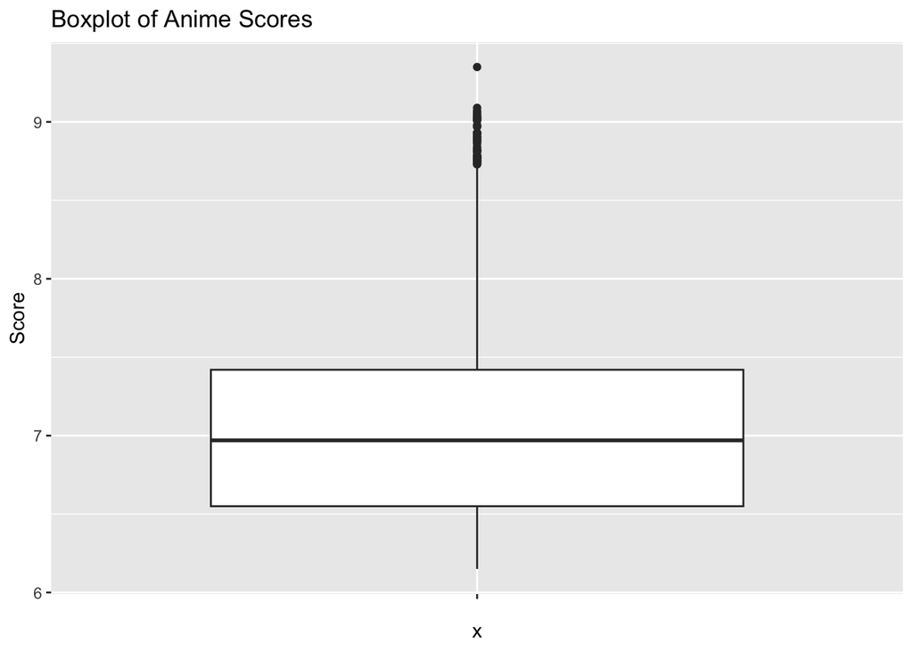

```r
# Boxplot for anime scores
ggplot(top_anime_cleaned, aes(x = "", y = Score)) +
  geom_boxplot() +
  labs(title = "Boxplot of Anime Scores",
       y = "Score")
```

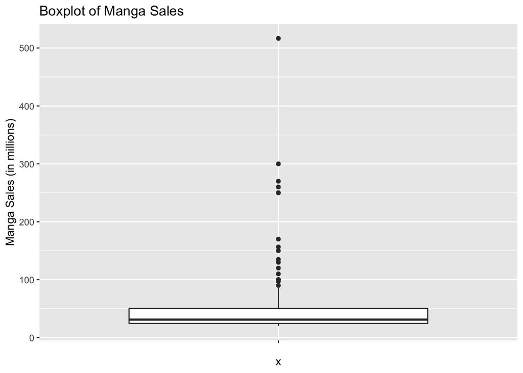

```r
# Boxplot for manga sales
ggplot(best_selling_manga_cleaned, aes(x = "", y = `Approximate sales in million(s)`)) +
  geom_boxplot() +
  labs(title = "Boxplot of Manga Sales",
       y = "Manga Sales (in millions)")
```

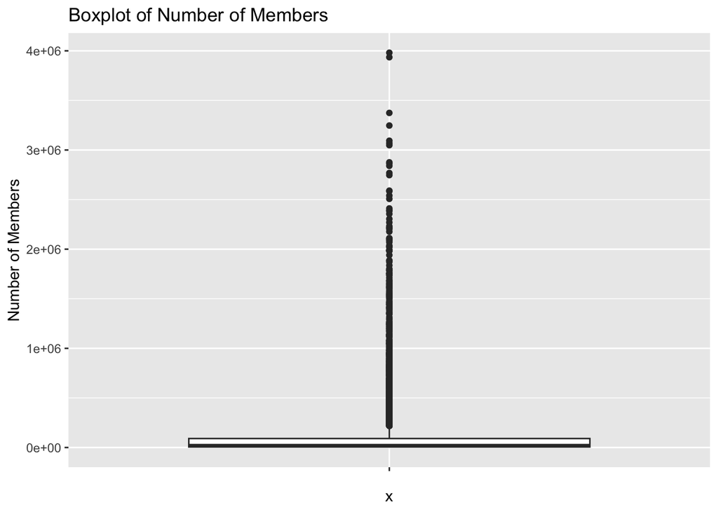

```r
# Boxplot for number of members
ggplot(top_anime_cleaned, aes(x = "", y = Members)) +
  geom_boxplot() +
  labs(title = "Boxplot of Number of Members",
       y = "Number of Members")
```

```r
# Identify outliers in anime scores
anime_score_outliers <- top_anime_cleaned %>%
  filter(Score < quantile(Score, 0.25) - 1.5 * IQR(Score) | Score > quantile(Score, 0.75) + 1.5 * IQR(Score))

# Identify outliers in manga sales
manga_sales_outliers <- best_selling_manga_cleaned %>%
  filter(`Approximate sales in million(s)` < quantile(`Approximate sales in million(s)`, 0.25) - 1.5 * IQR(`Approximate sales in million(s)`) |
         `Approximate sales in million(s)` > quantile(`Approximate sales in million(s)`, 0.75) + 1.5 * IQR(`Approximate sales in million(s)`))

# Identify outliers in number of members
members_outliers <- top_anime_cleaned %>%
  filter(Members < quantile(Members, 0.25) - 1.5 * IQR(Members) | Members > quantile(Members, 0.75) + 1.5 * IQR(Members))

# Print outliers
anime_score_outliers
```

| Title | Rank | Score | Members |
| --- | --- | --- | --- |
| Sousou no Frieren | 1 | 9.35 | 800615 |
| Fullmetal Alchemist: Brotherhood | 2 | 9.09 | 3373923 |
| Steins;Gate | 3 | 9.07 | 2584616 |
| Gintama° | 4 | 9.06 | 636631 |
| Shingeki no Kyojin Season 3 Part 2 | 5 | 9.05 | 2305044 |
| Gintama: The Final | 6 | 9.04 | 153317 |
| Gintama' | 7 | 9.03 | 561485 |
| Hunter x Hunter (2011) | 8 | 9.03 | 2863958 |
| Ginga Eiyuu Densetsu | 9 | 9.02 | 325595 |
| Gintama': Enchousen | 10 | 9.02 | 328147 |

[output cut: 41 more lines]

```r
manga_sales_outliers
```

| Manga series | Approximate sales in million(s) |
| --- | --- |
| One Piece | 516.6 |
| Golgo 13 | 300.0 |
| Case Closed / Detective Conan | 270.0 |
| Dragon Ball | 260.0 |
| Doraemon | 250.0 |
| Naruto | 250.0 |
| Slam Dunk | 170.0 |
| KochiKame: Tokyo Beat Cops | 156.5 |
| Demon Slayer: Kimetsu no Yaiba | 150.0 |
| Oishinbo | 135.0 |

[output cut: 10 more lines]

```r
members_outliers
```

| Title | Rank | Score | Members |
| --- | --- | --- | --- |
| Sousou no Frieren | 1 | 9.35 | 800615 |
| Fullmetal Alchemist: Brotherhood | 2 | 9.09 | 3373923 |
| Steins;Gate | 3 | 9.07 | 2584616 |
| Gintama° | 4 | 9.06 | 636631 |
| Shingeki no Kyojin Season 3 Part 2 | 5 | 9.05 | 2305044 |
| Gintama' | 7 | 9.03 | 561485 |
| Hunter x Hunter (2011) | 8 | 9.03 | 2863958 |
| Ginga Eiyuu Densetsu | 9 | 9.02 | 325595 |
| Gintama': Enchousen | 10 | 9.02 | 328147 |
| Bleach: Sennen Kessen-hen | 11 | 9.01 | 554516 |

[output cut: 1095 more lines]

The data wrangling process involved several key steps to prepare and clean the datasets for analysis. We began by loading the necessary packages (dplyr, tidyr, readr, and stringr) for data manipulation and importing. The structure of the datasets Anime_rank and best_selling_manga was inspected to understand their data types and arrangement. For the Top Anime Ranked dataset, we selected relevant columns (Title, Rank, Score, Members), removed rows with missing values in key columns, and trimmed whitespace from the Title column. Similarly, for the Best-Selling Manga dataset, we selected relevant columns (Manga series, Approximate sales in million(s)), removed rows with missing values, and trimmed whitespace from the Manga series column. The cleaned datasets were then merged using an inner join on the Title and Manga series columns, combining the datasets based on matching titles. Additionally, we created two wrangled datasets: the top 50 anime by score and the top 50 manga by sales, by arranging the data in descending order of scores and sales, respectively, and selecting the top entries.

## Data Visualization

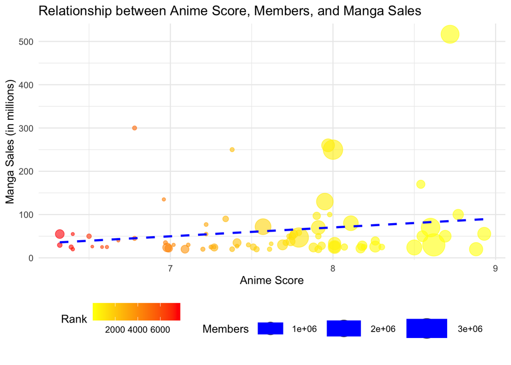

```r
library(ggplot2)

# Create a scatter plot with a regression line
plot1 <- ggplot(merged_data, aes(x = Score, y = `Approximate sales in million(s)`, size = Members, color = Rank)) +
  geom_point(alpha = 0.6) +
  geom_smooth(method = "lm", se = FALSE, color = "blue", linetype = "dashed") +
  scale_size_continuous(range = c(1, 10), name = "Members") +
  scale_color_gradient(low = "yellow", high = "red", name = "Rank") +
  labs(title = "Relationship between Anime Score, Members, and Manga Sales",
       x = "Anime Score",
       y = "Manga Sales (in millions)") +
  theme_minimal() +
  theme(legend.position = "bottom")

# Print the plot
print(plot1)
```

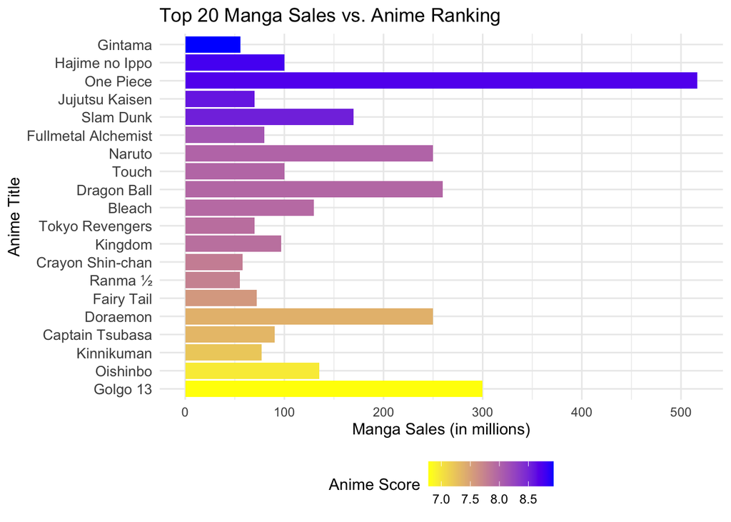

```r
# Select the top 20 manga by sales
top_20_manga <- merged_data %>%
  arrange(desc(`Approximate sales in million(s)`)) %>%
  head(20)

# Create a bar plot to show the relationship between manga sales and anime ranking
plot2 <- ggplot(top_20_manga, aes(x = reorder(Title, -Rank), y = `Approximate sales in million(s)`, fill = Score)) +
  geom_bar(stat = "identity") +
  coord_flip() +
  scale_fill_gradient(low = "yellow", high = "blue", name = "Anime Score") +
  labs(title = "Top 20 Manga Sales vs. Anime Ranking",
       x = "Anime Title",
       y = "Manga Sales (in millions)") +
  theme_minimal() +
  theme(legend.position = "bottom",
        axis.text.y = element_text(size = 10))

# Print the plot
print(plot2)
```

This bar plot visualizes the relationship between the popularity of the top 20 manga (measured by approximate sales) and the ranking of their anime adaptations. By focusing on the top 20 manga, this plot highlights specific cases where high manga sales correlate with high anime rankings, making it easier to identify patterns and outliers.

## Conclusion

Our analysis sought to answer the research question: **“Is there a correlation between the popularity of manga and the ranking of their anime adaptations?”** Using comprehensive datasets from Kaggle, we examined the top-ranked anime and best-selling manga series, focusing on key variables such as anime scores, member counts, and manga sales.

The scatter plot visualizing the relationship between anime scores, manga sales, and member counts suggested a positive correlation. Higher manga sales generally corresponded to higher anime scores, and popular anime (with more members) often had higher sales figures. For instance, in the first ggplot graph, anime titles with high member counts and high scores, such as “One Piece,” demonstrated significant manga sales, reinforcing the observed trend.

From our initial intuition and the visualizations, we observe a trend where popular manga tend to have successful anime adaptations. However, the correlation is not absolute; high manga sales do not always guarantee a top-ranked anime adaptation. Factors such as production quality, fidelity to the source material, and audience reception significantly influence the success of an anime adaptation.

In conclusion, while there is some correlation between manga popularity and anime rankings, it is not a definitive predictor. The success of an anime adaptation is multifaceted, and manga popularity is just one of many contributing factors. Our findings highlight the complexity of the relationship between manga sales and anime success, suggesting that future research could delve deeper into other influential factors to provide a more comprehensive understanding.